# Chapter10_Lab3

# Optimal Matching

We first learn how to calculate a distance or a similarity measure between sequences. `TraMineR` offers several functions to determine similarity between sequences. The `seqdist` function offers several direct measures based on the count of common attributes, such as HAM (Simple Hamming distance), LCP (Longest Common Prefix), RLCP same as LCP but counts in reverse, and LCS (Longest Common Subsequence). To understand these measures further please refer to chapter 10, where these methods are defined in more depth. Here we will just apply them and compare them.

```r
#distance measures between the 10 sequences.

#HAM distance measure - Does not work with sequences of different length. To run HAM distance, change the script in the section above to output equal length subsequences. Otherwise, comment out the line below to continue.
#seqdist(playerData.seq[105:115,], method ="HAM")

#LCP distance measure
seqdist(playerData.seq[105:115,], method ="LCP")
```

```
##  [>] 11 sequences with 11 distinct states
```

```
##  [>] 11 distinct  sequences
```

```
##  [>] min/max sequence lengths: 46/118
```

```
##  [>] computing distances using the LCP metric
```

```
##  [>] elapsed time: 0.064 secs
```

```
##       [,1] [,2] [,3] [,4] [,5] [,6] [,7] [,8] [,9] [,10] [,11]
##  [1,]    0  175  194  176  206  172  157  192  205   126   131
##  [2,]  175    0  195  177  207  173  158  193  206   139   132
##  [3,]  194  195    0  194  216  186  167  202  223   158   151
##  [4,]  176  177  194    0  206  172  157  192  203   140   133
##  [5,]  206  207  216  206    0  198  179  214  235   170   163
##  [6,]  172  173  186  172  198    0  149  184  201   136   129
##  [7,]  157  158  167  157  179  149    0  157  186   121   114
##  [8,]  192  193  202  192  214  184  157    0  221   156   149
##  [9,]  205  206  223  203  235  201  186  221    0   169   162
## [10,]  126  139  158  140  170  136  121  156  169     0    95
## [11,]  131  132  151  133  163  129  114  149  162    95     0
```

```r
#LCS distance measure
seqdist(playerData.seq[105:115,], method ="LCS")
```

```
##  [>] 11 sequences with 11 distinct states
```

```
##  [>] creating a 'sm' with a substitution cost of 2
```

```
##  [>] creating 11x11 substitution-cost matrix using 2 as constant value
```

```
##  [>] 11 distinct  sequences
```

```
##  [>] min/max sequence lengths: 46/118
```

```
##  [>] computing distances using the LCS metric
```

```
##  [>] elapsed time: 0.069 secs
```

```
##       [,1] [,2] [,3] [,4] [,5] [,6] [,7] [,8] [,9] [,10] [,11]
##  [1,]    0   49   84   50   66   50   39   56   63    38    47
##  [2,]   49    0   87   49   57   55   54   53   60    49    48
##  [3,]   84   87    0   94  106   80   75  100   87    72    69
##  [4,]   50   49   94    0   62   46   49   54   63    38    47
##  [5,]   66   57  106   62    0   68   67   56   61    70    71
##  [6,]   50   55   80   46   68    0   39   56   65    38    41
##  [7,]   39   54   75   49   67   39    0   57   66    21    26
##  [8,]   56   53  100   54   56   56   57    0   63    54    59
##  [9,]   63   60   87   63   61   65   66   63    0    71    74
## [10,]   38   49   72   38   70   38   21   54   71     0    15
## [11,]   47   48   69   47   71   41   26   59   74    15     0
```

Optimal Matching is another distance measure that would depend on how much it would cost to turn one sequence into another. Thus, a cost function is required from the user. `TraMineR` allows you to set the cost function using the function `seqsubm`. Two methods can be used with this function, a constant cost for each operation or a `TRATE` cost which is based on probability of observing the state, which would penalize changes that are not frequently observed.

```r
#setting substitution cost using frequency measures
seqcost.trate <- seqsubm(playerData.seq, method = "TRATE")
```

```
##  [>] creating substitution-cost matrix using transition rates ...
```

```
##  [>] computing transition probabilities for states solo/fight/kill_hero/teaming/death/harrassed_by_opponents/fight_diminishes/fight_intensifies/team_fight/full_team_assembly/  ...
```

```r
round(seqcost.trate, 3)
```

```
##                          solo-> fight-> kill_hero-> teaming-> death->
## solo->                    0.000   1.444       1.630     1.459   1.406
## fight->                   1.444   0.000       1.860     1.851   1.703
## kill_hero->               1.630   1.860       0.000     1.669   1.852
## teaming->                 1.459   1.851       1.669     0.000   1.796
## death->                   1.406   1.703       1.852     1.796   0.000
## harrassed_by_opponents->  2.000   1.983       1.938     1.987   1.867
## fight_diminishes->        1.274   1.960       2.000     1.766   2.000
## fight_intensifies->       1.997   1.906       2.000     1.863   2.000
## team_fight->              2.000   1.999       1.912     1.999   1.832
## full_team_assembly->      1.750   2.000       1.748     1.749   2.000
##  ->                       2.000   2.000       2.000     2.000   2.000
##                          harrassed_by_opponents-> fight_diminishes->
## solo->                                      2.000              1.274
## fight->                                     1.983              1.960
## kill_hero->                                 1.938              2.000
## teaming->                                   1.987              1.766
## death->                                     1.867              2.000
## harrassed_by_opponents->                    0.000              1.240
## fight_diminishes->                          1.240              0.000
## fight_intensifies->                         1.906              1.388
## team_fight->                                2.000              1.250
## full_team_assembly->                        2.000              2.000
##  ->                                         2.000              2.000
##                          fight_intensifies-> team_fight-> full_team_assembly->
## solo->                                 1.997        2.000                1.750
## fight->                                1.906        1.999                2.000
## kill_hero->                            2.000        1.912                1.748
## teaming->                              1.863        1.999                1.749
## death->                                2.000        1.832                2.000
## harrassed_by_opponents->               1.906        2.000                2.000
## fight_diminishes->                     1.388        1.250                2.000
## fight_intensifies->                    0.000        1.925                2.000
## team_fight->                           1.925        0.000                2.000
## full_team_assembly->                   2.000        2.000                0.000
##  ->                                    2.000        2.000                2.000
##                           ->
## solo->                     2
## fight->                    2
## kill_hero->                2
## teaming->                  2
## death->                    2
## harrassed_by_opponents->   2
## fight_diminishes->         2
## fight_intensifies->        2
## team_fight->               2
## full_team_assembly->       2
##  ->                        0
```

```r
#setting substitution cost using constant measure, cval is the constant cost
seqcost.constant <- seqsubm(playerData.seq, method = "CONSTANT", cval = 3)
```

```
##  [>] creating 11x11 substitution-cost matrix using 3 as constant value
```

```r
round(seqcost.constant)
```

```
##                          solo-> fight-> kill_hero-> teaming-> death->
## solo->                        0       3           3         3       3
## fight->                       3       0           3         3       3
## kill_hero->                   3       3           0         3       3
## teaming->                     3       3           3         0       3
## death->                       3       3           3         3       0
## harrassed_by_opponents->      3       3           3         3       3
## fight_diminishes->            3       3           3         3       3
## fight_intensifies->           3       3           3         3       3
## team_fight->                  3       3           3         3       3
## full_team_assembly->          3       3           3         3       3
##  ->                           3       3           3         3       3
##                          harrassed_by_opponents-> fight_diminishes->
## solo->                                          3                  3
## fight->                                         3                  3
## kill_hero->                                     3                  3
## teaming->                                       3                  3
## death->                                         3                  3
## harrassed_by_opponents->                        0                  3
## fight_diminishes->                              3                  0
## fight_intensifies->                             3                  3
## team_fight->                                    3                  3
## full_team_assembly->                            3                  3
##  ->                                             3                  3
##                          fight_intensifies-> team_fight-> full_team_assembly->
## solo->                                     3            3                    3
## fight->                                    3            3                    3
## kill_hero->                                3            3                    3
## teaming->                                  3            3                    3
## death->                                    3            3                    3
## harrassed_by_opponents->                   3            3                    3
## fight_diminishes->                         3            3                    3
## fight_intensifies->                        0            3                    3
## team_fight->                               3            0                    3
## full_team_assembly->                       3            3                    0
##  ->                                        3            3                    3
##                           ->
## solo->                     3
## fight->                    3
## kill_hero->                3
## teaming->                  3
## death->                    3
## harrassed_by_opponents->   3
## fight_diminishes->         3
## fight_intensifies->        3
## team_fight->               3
## full_team_assembly->       3
##  ->                        0
```

We then need to set the distance function based on optimal matching and the cost function.

```r
#setting the distance using OM=Optimal Matching method with the TRATE cost
#indel = 1 here means that we are setting the cost for insertions and deletions to 1
playerData.om <- seqdist(playerData.seq, method="OM", indel = 1, sm=seqcost.trate)
```

```
##  [>] 200 sequences with 11 distinct states
```

```
##  [>] checking 'sm' (size and triangle inequality)
```

```
##  [>] 200 distinct  sequences
```

```
##  [>] min/max sequence lengths: 38/127
```

```
##  [>] computing distances using the OM metric
```

```
##  [>] elapsed time: 0.426 secs
```

# Finding the Most Representative Sequence given Optimal Matching Distance

Another method that can be handy is to use the distance measure to determine most common or central sequence given the dataset. To do this we can use the `seqrep` function, as shown below.

```
##  [!!] In rmarkdown::render() : fontsize is deprecated, use cex instead.
```

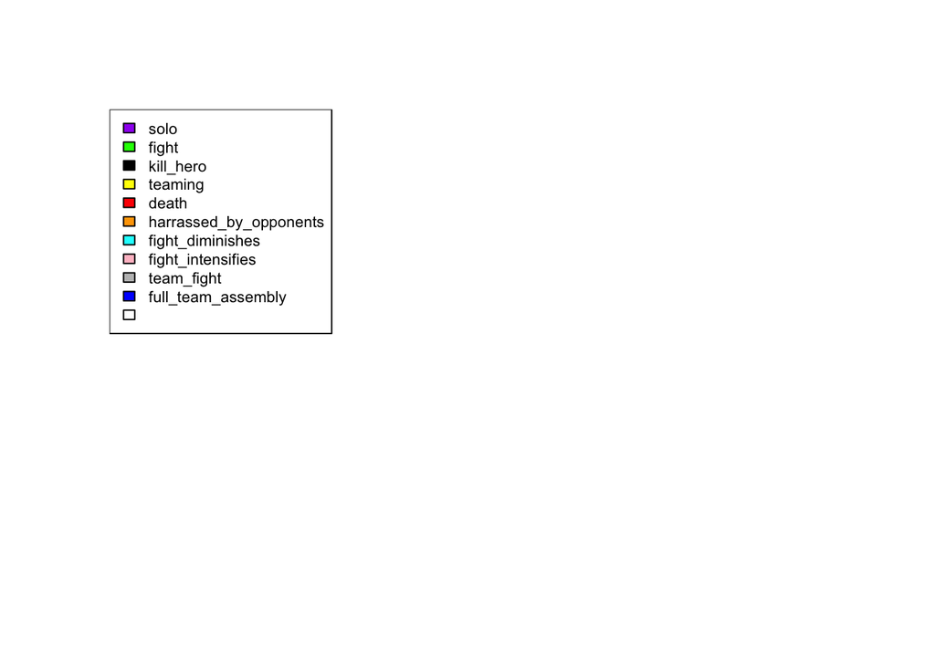

```r
#create a legend for the data charts below
seqlegend(playerData.seq, fontsize = .7)
```

```r
#Rep sequence based on density criterion
RepSequence2 <- seqrep(playerData.seq, diss = playerData.om, nrep=1)
```

```
##  [>] number of objects (sum of weights): 200
```

```
##  [>] max. distance: 99.66
```

```
##  [>] neighborhood radius: 9.97
```

```
##  [>] 1 representative(s) selected
```

```
##  [>] 200 distinct sequence(s)
```

```r
RepSequence2
```

|  | op_num.1 | op_num.2 | op_num.3 | op_num.4 | op_num.5 | op_num.6 | op_num.7 | op_num.8 | op_num.9 | op_num.10 | op_num.11 | op_num.12 | op_num.13 | op_num.14 | op_num.15 | op_num.16 | op_num.17 | op_num.18 | op_num.19 | op_num.20 | op_num.21 | op_num.22 | op_num.23 | op_num.24 | op_num.25 | op_num.26 | op_num.27 | op_num.28 | op_num.29 | … |
| --- | --- | --- | --- | --- | --- | --- | --- | --- | --- | --- | --- | --- | --- | --- | --- | --- | --- | --- | --- | --- | --- | --- | --- | --- | --- | --- | --- | --- | --- | --- |
| [1] | solo | solo | solo | solo | solo | fight | solo | solo | solo | solo | solo | solo | solo | solo | solo | solo | solo | solo | solo | solo | solo | solo | solo | solo | teaming | solo | solo | solo | solo | … |

```
##  [>] number of objects (sum of weights): 200
```

```
##  [>] max. distance: 99.66
```

```
##  [>] neighborhood radius: 9.97
```

```
##  [>] 46 representative(s) selected, coverage=25% (threshold=25%)
```

```
##  [>] 200 distinct sequence(s)
```

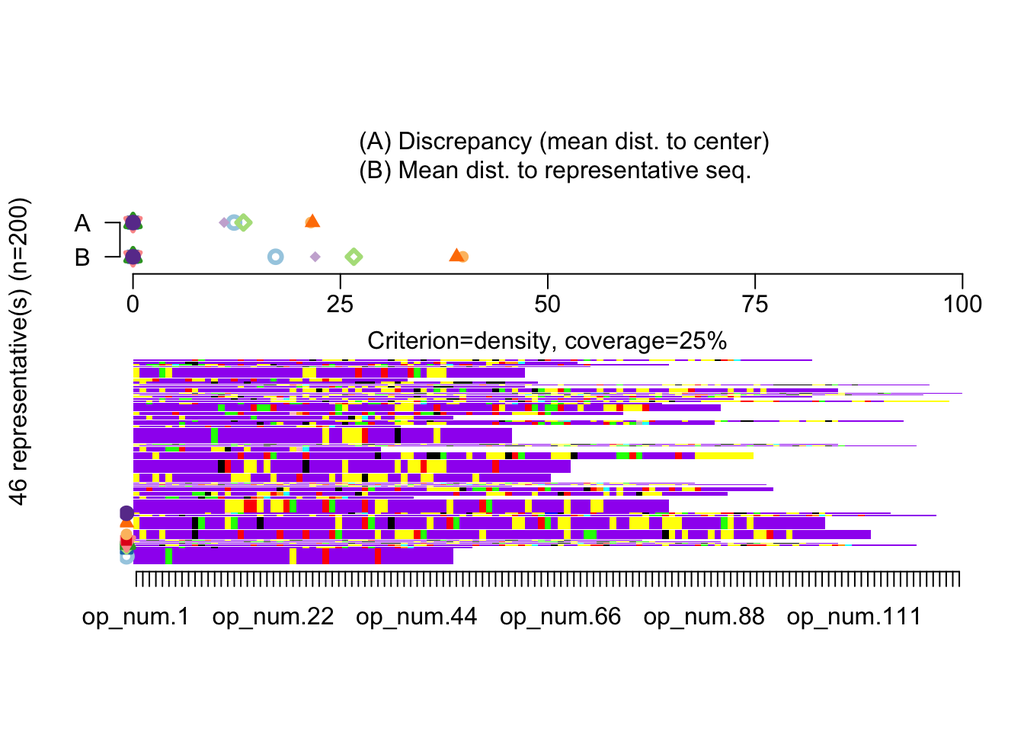

```r
seqrplot(playerData.seq, diss=playerData.om, border=NA, with.legend ="FALSE")
```

# Clustering

For clustering we will use the heirarchical clustering algorithm provided by the cluster library and the function agnes. You should already know how to do this since we discussed it in Chapter 6 and showed how to perform this in R in Lab 6.4. For a distance measure, we will use the data matrix produced by the OM method.

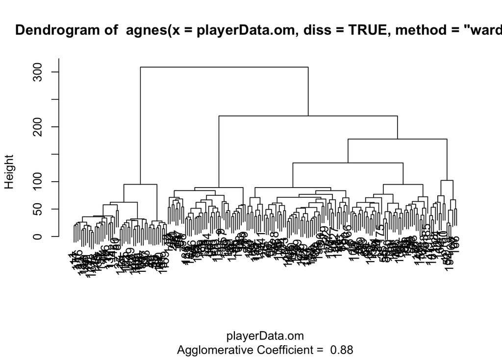

```r
#load cluster library
library(cluster)
#use heirarchical clustering on the distance matrix produced by OM method
clusterward <- agnes (playerData.om, diss=TRUE, method="ward")
plot (clusterward, which.plots=2)
```

```r
#cut the tree at 4
cluster4 <- cutree(clusterward, k=4)
#display the table of the counts of the different types
cluster4 <- factor(cluster4, labels= c("Type 1", "Type 2", "Type 3", "Type 4"))
table(cluster4)
```

```
## cluster4
## Type 1 Type 2 Type 3 Type 4
##     49     41     95     15
```

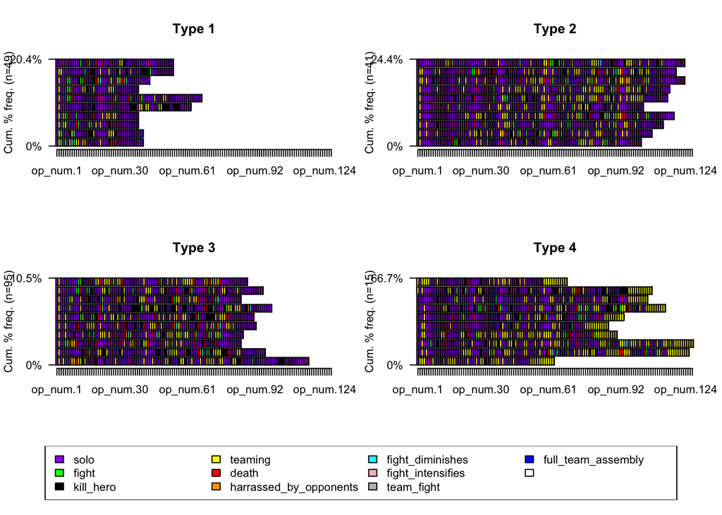

```r
#plot the cluster most frequent sequences
seqfplot(playerData.seq, group=cluster4, pbarw=T)
```

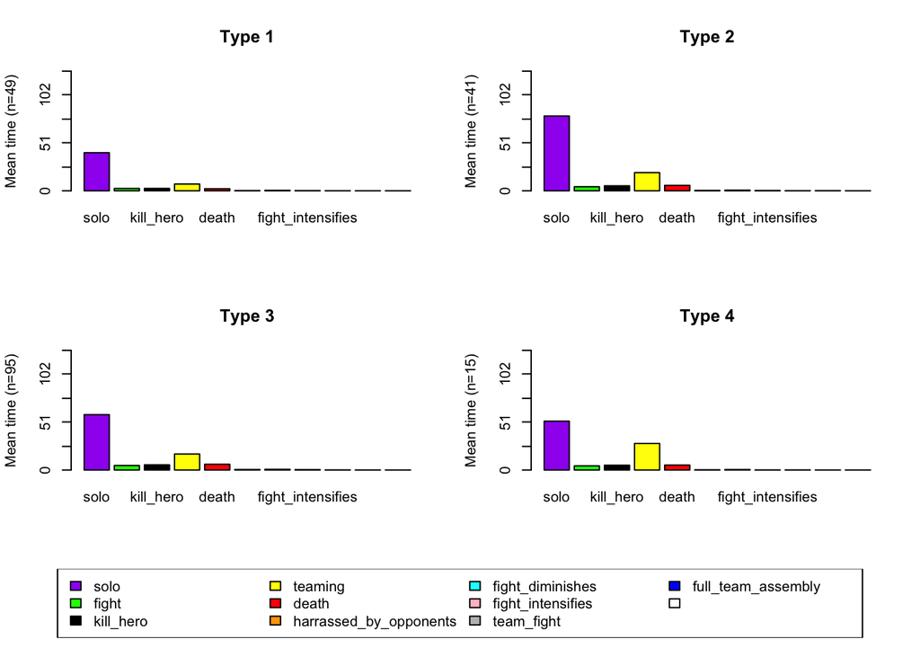

```r
#plot the bar chart of the operations and their mean occurances
seqmtplot(playerData.seq, group=cluster4)
```

In conclusion, this lab showed you how to use various methods to determine distance between sequences. We focused on Optimal Matching and showed how to use such a distance measure as an input to a clustering method we learned about in Chapter 6 to see how the data clusters. We leave it as an exercise for you to interpret the clustering results in terms of the qualitative meaning of these clusters to evaluate the use of Optimal Matching given this data.